# act_report

## WeRateDogs Analysis

### Project Overview

WeRateDogs is a twitter account that started in 2015. The account rates people's dogs with humorous comment about the dog. WeRateDogs has over 4 million followers and has received international coverage

### Analysis

In this analysis, a trend is recognised in the number of favorites and the number of retweets. In the figure below we see a positive correlation between the the number of retweets and the number of favorites. This shows that there is a high engagement of the WeRateDogs twitter account which reflects followers interests and preferences with dogs

```python
import pandas as pd
twitter_archive_master = pd.read_csv('twitter_archive_master.csv')
```

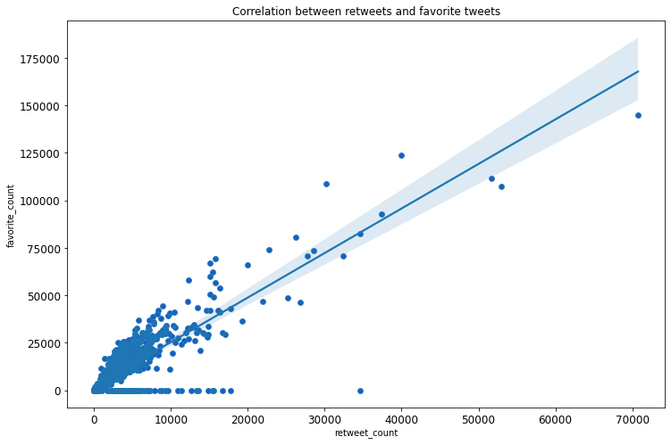

```python
#regression plot
import seaborn as sns
twitter_archive_master.plot.scatter(x= 'retweet_count', y= 'favorite_count', color = 'blue', fontsize=12, figsize = (12,8),subplots = True);
plt.xlabel('number of retweeted tweets');
plt.ylabel('number of favorite tweets');
plt.title('Correlation between retweets and favorite tweets');

sns.regplot(x='retweet_count', y='favorite_count',data = twitter_archive_master);
```

```python
twitter_archive_master.groupby(['stage']).favorite_count.sum().sort_values(ascending=False)
```

```
stage
pupper           1259079
doggo            1090715
puppo             430360
doggo,pupper      108286
floofer            78555
doggo,puppo        41897
doggo,floofer      14843
Name: favorite_count, dtype: int64
```

[figure not shown]

```python
#visualizing dog stages to show most lovedb dog stage
import matplotlib.pyplot as plt
labels = twitter_archive_master.stage.unique().tolist()[1:]
sizes = twitter_archive_master.groupby(['stage']).favorite_count.sum().sort_values(ascending=False).tolist()
fig1, ax1 = plt.subplots()
ax1.pie(sizes,shadow=True)
plt.legend(labels)
ax1.axis('equal')

plt.show();
```

We can also see the top rated dogs according to the 4 million followers from the analysis below. It is confirmed that the top rated dog stage with the highest rating are pupper and doggo

```python
#top rated dog stage
twitter_archive_master.query('rating_numerator == 14').stage.value_counts()
```

```
pupper    9
doggo     9
puppo     1
Name: stage, dtype: int64
```